# Cardio Good Fitness EDA

**Objective** - Preliminary Data Analysis. Explore the dataset and and extract basic observations about the data. **Expectations:**

- Come up with a customer profile (characteristics of a customer) of the different products
- Perform uni-variate and multi-variate analyses
- Generate a set of insights and recommendations that will help the company in targeting new customers

**Context** The data is for customers of the treadmill product(s) of a retail store called Cardio Good Fitness. It contains the following variables:

- Product - the model no. of the treadmill
- Age - in no of years, of the customer
- Gender - of the customer
- Education - in no. of years, of the customer
- Marital Status - of the customer
- Usage - Avg. # times the customer wants to use the treadmill every week
- Fitness - Self rated fitness score of the customer (5 - very fit, 1 - very unfit)
- Income - of the customer
- Miles- expected to run

# I. Executive Summary

*NOTE:* Product Findings are based solely on data contained within the dataset

### The Following Section Identify Shared Characteristics For Customers Across Each Product

#### Common Characteristics Shared Across All 3 Products

*The following is a summary of characteristcs common across all three products (TM195, TM498, TM798)*

- All three products show higher adoption by customers whose education aligns with key academic milestones (Associate, Bachelor, and Graduate degrees)
- Customers for all three products appear to align with an age bracket of ~19 to 47, with the median age of customer being ~26/27 years old. Though users who purchased the TM798 appear to be in a more focused subset of the age range.
- There appears to be a positively skewed (right-skewed) distribution in regards to Age.
- There appears to be a positively skewed (right-skewed) distribution in regards to Expected Miles Run.
- All three products show a similar ratio between single and partnered customers, with Couples out numbering Individuals
- A positive coorelation appears to exist between income and education for all three products

#### Characteristics Shared By TM195 and TM498 Customers

*The following is a summary of characteristcs associated with customers who purchased the TM195 and TM498*

- Customers who purchase the TM195 and TM498 have the same median age of ~26 with 50% of customers within each product category falling into a similar box range of ~24 to ~34.
- Customers who purchase the TM195 and TM498 appear to rate themselves as a fitness level of 3.
- Customer who purchase the TM195 and TM498 appear to align with the same key academic milestones (Associate and Bachelor)
- Unlike customers who purchase the TM798, there does NOT appear to be a positive correlation between Income and expected miles run for customer who purchased the TM195 and TM498
- Unlike customers who purchase the TM798, there does NOT appear to be a correlation between Income and the self rating of fitness level for customer who purchased the TM195 and TM498
- Unlike customers who purchase the TM798, there does NOT appear to be a strong correlation between Age and the self rating of fitness level for customer who purchased the TM195 and TM498
- The TM195 and TM498 appear to have equal prepresentation based on Gender.

### The Following Section Identify Unique Characteristics For Customers of Each Product

#### Unique Characteristics Associated with TM798 Customers

*The following is a summary of characteristcs associated with customers who purchased the TM798*

- Median Income of \$75k with a range of \$50k - \$105k. 50 percent of customers fall within the Income of \$60k - \$90k.
- Males appear to be far more likely to purchase the TM798, with female customers representing only 17.5 percent of owners. ***Note*** As the TM798 is showing a higher engagement with couples this may be due to units being purchased and associated with males, verify data.
- Customers rate themselves at the higher end of the fitness scale
- Customers achieved a higher education level than typically associated with the TM195 and TM498
- Couples appear to set higher goals in regard to expected miles run
- There appears to be a positive correlation between income and expected miles run.
- There appears to be a positive correlation between income and self rating of fitness level.
- There appears to be a positive correlation between Age and self rating of fitness level.
- Customers who purchase the TM798 appear to rate themselves as a fitness level of 3 or higher, with 50 percent of customers ratingin themselves as 4.0 - 5.0.

### The Following Section Provides Buyer Persona's For Each Product

#### Buyer Persona for TM195

- Beginner to intermediate user.
- Recent college graduate (Community College or Undergraduate).
- Young professional 1 - 3 years of work experience.

#### Buyer Persona for TM498

- Beginner to intermediate user.
- Recent college graduate (Community College or Undergraduate).
- Young professional 3 - 7 years of work experience.
- The TM498 is an upsell opportunity for potential buyers of the TM195

#### Buyer Persona for TM798

- Intermediate to advanced user.
- Recent college graduate, specifically graduate level or higher.
- Working professional 5+ years of work experience.
- Married couple or couple shopping together
- Conduct further research into Gender disparity and determine if product features need to be address or improved marketing strategies.

# II. Load Data and Necessary Libraries

### Import necessary libraries and dataset

```python
import numpy as np
import pandas as pd
import pandas_profiling as pp
import seaborn as sns
import matplotlib.pyplot as plt
sns.set_theme(style="white", rc={"axes.facecolor": (0, 0, 0, 0)})
%matplotlib inline

data = pd.read_csv("CardioGoodFitness.csv")
```

### Create a Pandas Profile Report

```python
pp.ProfileReport(data)
```

[interactive chart not shown]

### View the first 5 rows of all the datasets.

```python
data.head()
```

|  | Product | Age | Gender | Education | MaritalStatus | Usage | Fitness | Income | Miles |
| --- | --- | --- | --- | --- | --- | --- | --- | --- | --- |
| 0 | TM195 | 18 | Male | 14 | Single | 3 | 4 | 29562 | 112 |
| 1 | TM195 | 19 | Male | 15 | Single | 2 | 3 | 31836 | 75 |
| 2 | TM195 | 19 | Female | 14 | Partnered | 4 | 3 | 30699 | 66 |
| 3 | TM195 | 19 | Male | 12 | Single | 3 | 3 | 32973 | 85 |
| 4 | TM195 | 20 | Male | 13 | Partnered | 4 | 2 | 35247 | 47 |

### Review the shape of the dataset.

```python
data.shape
```

```
(180, 9)
```

### Reviw data types of the columns for the datasets.

```python
data.dtypes
```

```
Product          object
Age               int64
Gender           object
Education         int64
MaritalStatus    object
Usage             int64
Fitness           int64
Income            int64
Miles             int64
dtype: object
```

**Observations:**

1. Product, Gender and MaritalStatus are of string data type
2. All other fields are of Integer type

### Statistical summary for all the datasets.

```python
data.describe()
```

|  | Age | Education | Usage | Fitness | Income | Miles |
| --- | --- | --- | --- | --- | --- | --- |
| count | 180.000000 | 180.000000 | 180.000000 | 180.000000 | 180.000000 | 180.000000 |
| mean | 28.788889 | 15.572222 | 3.455556 | 3.311111 | 53719.577778 | 103.194444 |
| std | 6.943498 | 1.617055 | 1.084797 | 0.958869 | 16506.684226 | 51.863605 |
| min | 18.000000 | 12.000000 | 2.000000 | 1.000000 | 29562.000000 | 21.000000 |
| 25% | 24.000000 | 14.000000 | 3.000000 | 3.000000 | 44058.750000 | 66.000000 |
| 50% | 26.000000 | 16.000000 | 3.000000 | 3.000000 | 50596.500000 | 94.000000 |
| 75% | 33.000000 | 16.000000 | 4.000000 | 4.000000 | 58668.000000 | 114.750000 |
| max | 50.000000 | 21.000000 | 7.000000 | 5.000000 | 104581.000000 | 360.000000 |

### Create DataFrames from the 3 datasets

```python
cardio_df = pd.DataFrame(data)
```

#### Create seperate DataFrames for each product

```python
tm195 = cardio_df[cardio_df['Product'] == 'TM195']
tm498 = cardio_df[cardio_df['Product'] == 'TM498']
tm798 = cardio_df[cardio_df['Product'] == 'TM798']
```

# III. Begin Analysis

*The following sections present the working components of the analysis*

#### Create a pairplot for a quick visual review

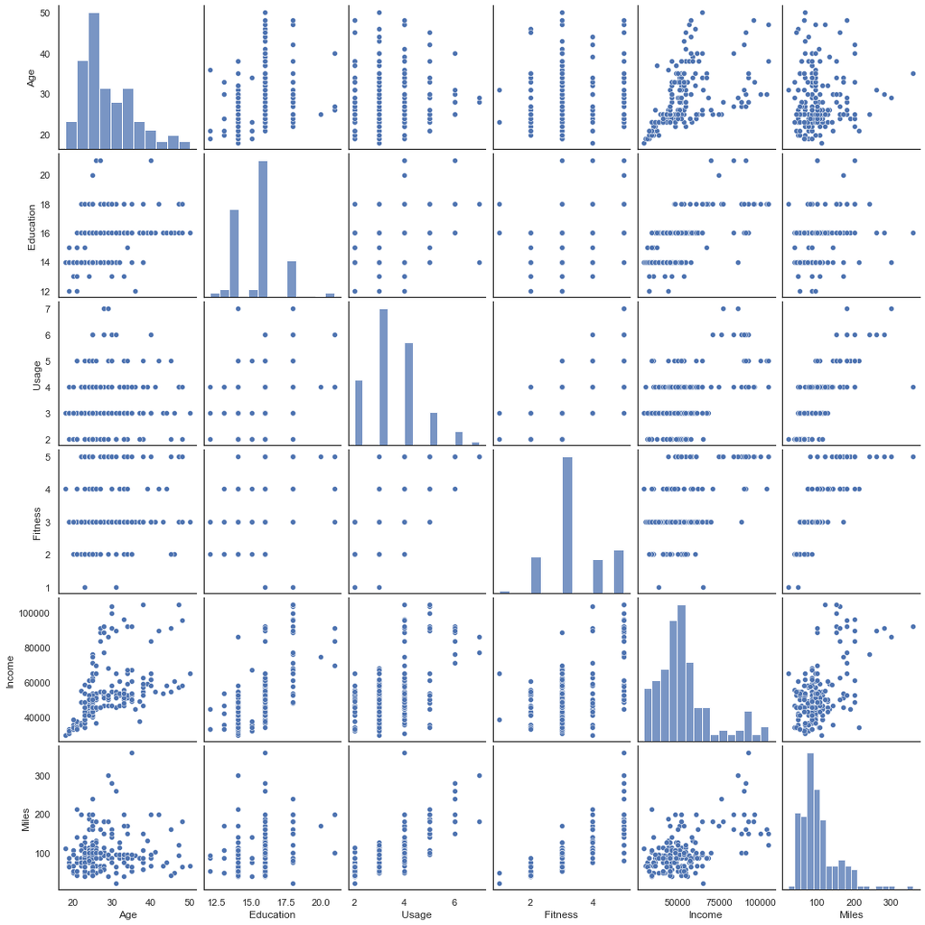

```python
sns.pairplot(cardio_df);
```

## Review of Products by Age

Is there a variation in product selection based on the age of the customer?

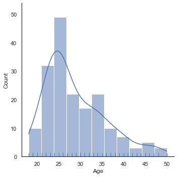

```python
sns.displot(cardio_df['Age'], kde = True, rug = True);
```

**Observations:**

1. The median age of customer within the dataset is ~25 years old
2. There appears to be a positively skewed (right-skewed) distribution in regards to age

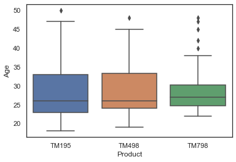

```python
sns.boxplot(x=cardio_df['Product'], y=cardio_df['Age']);
```

**Observations:**

1. TM195 and TM498 are very similar in regards to age
2. Customers who purchased the TM798 appear to be a smaller more focused subset of the age range associated with the other two products.
3. The TM798 has a larger number of outliers
4. The median age of customer for all products is relatively the same

## Review of Products by Income

Is there a variation in product selection based on the income of the customer?

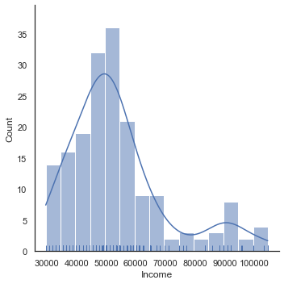

```python
sns.displot(cardio_df['Income'], kde = True, rug = True);
```

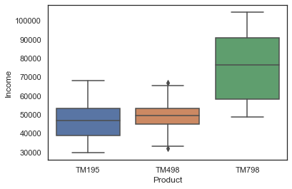

```python
sns.boxplot(x=cardio_df['Product'], y=cardio_df['Income']);
```

**Observations:**

1. Based on income TM195 and TM498 appear to be a relevent to the similar user segment
2. Customers who purchased the TM798 generally have a higher income than customers who purchased th TM195 and T498
3. 50% of customers who purchased the TM195 have an annual income between \$40k and \\$55k
4. 50% of customers who purchased the TM498 have an annual income between \$45k and \\$55k
5. 50% of customers who purchased the TM798 have an annual income between \$60k and \\$90k

## Review of Products by Education

Is there a variation in product selection based on the Education of the customer?

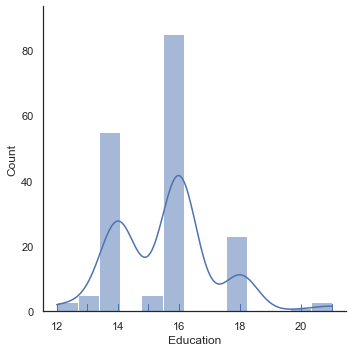

```python
sns.displot(cardio_df['Education'], kde = True, rug = True,);
```

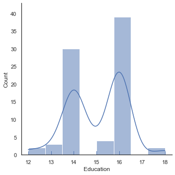

```python
sns.displot(tm195['Education'], kde = True, rug = True,);
```

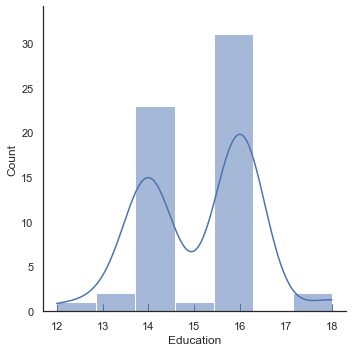

```python
sns.displot(tm498['Education'], kde = True, rug = True,);
```

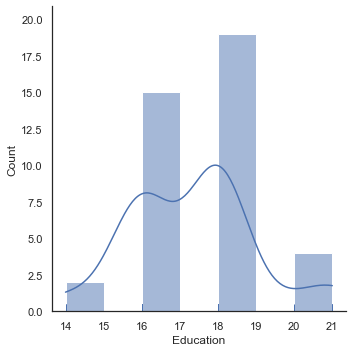

```python
sns.displot(tm798['Education'], kde = True, rug = True,);
```

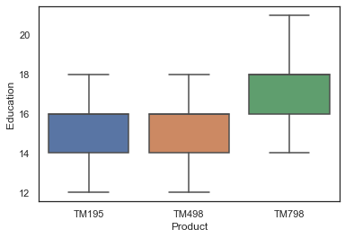

```python
sns.boxplot(x=cardio_df['Product'], y=cardio_df['Education']);
```

**Observations:**

1. Iterestingly it looks like the customer clusters are strongest at education levels that correspond to key academic milestones such as receiving an Associate, Bachelor or Graduate degree.

## Review of Products by Fitness

Is there a variation in product selection based on the fitness level of the customer?

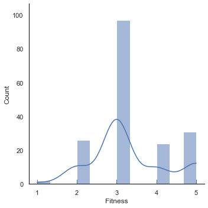

```python
sns.displot(cardio_df['Fitness'], kde = True, rug = True);
```

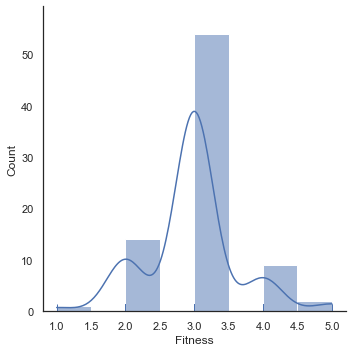

```python
sns.displot(tm195['Fitness'], kde = True, rug = True);
```

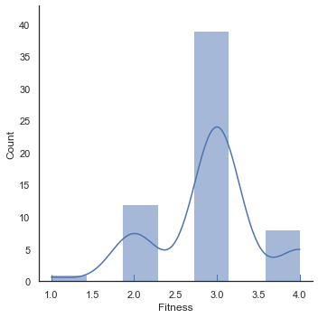

```python
sns.displot(tm498['Fitness'], kde = True, rug = True);
```

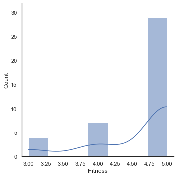

```python
sns.displot(tm798['Fitness'], kde = True, rug = True);
```

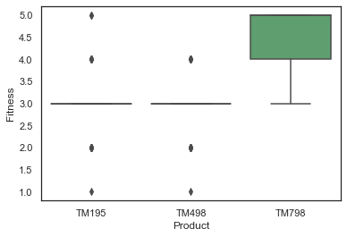

```python
sns.boxplot(x=cardio_df['Product'], y=cardio_df['Fitness']);
```

**Observations:**

1. TM195 and TM498 appear to be very similar regarding Fitness self-assessment.
2. Customers who bought the TM798 appear to have a higher self-assessment egarding fitness level.

## Review of Products by Miles

Is there a variation in product selection based on the expected miles of use per customer?

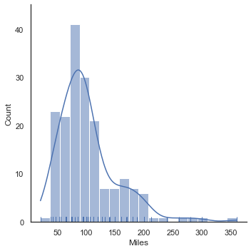

```python
sns.displot(cardio_df['Miles'], kde = True, rug = True);
```

**Observations:**

1. Strong right-skewed sitribution regarding expected miles.

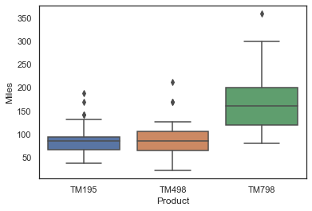

```python
sns.boxplot(x=cardio_df['Product'], y=cardio_df['Miles']);
```

**Observations:**

1. Owners of the TM798 appear to set larger goals for themeselves.

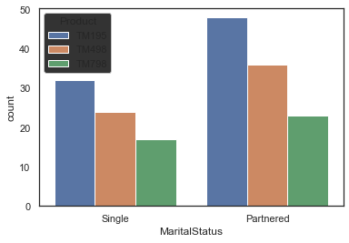

```python
sns.countplot(x='MaritalStatus', hue='Product',data=cardio_df);
```

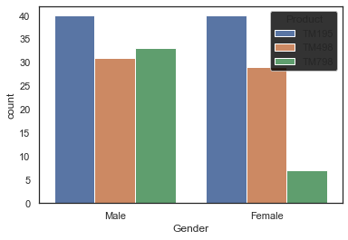

```python
sns.countplot(x='Gender', hue='Product',data=cardio_df);
```

*Get additional insights regarding gender and the TM798*

```python
total_gender_tm798 = tm798['Gender'].count()
total_female_tm798 = tm798[tm798['Gender'] == 'Female'].count()

female_usage_tm798 = total_female_tm798 / total_gender_tm798
female_usage_tm798
```

```
Product          0.175
Age              0.175
Gender           0.175
Education        0.175
MaritalStatus    0.175
Usage            0.175
Fitness          0.175
Income           0.175
Miles            0.175
dtype: float64
```

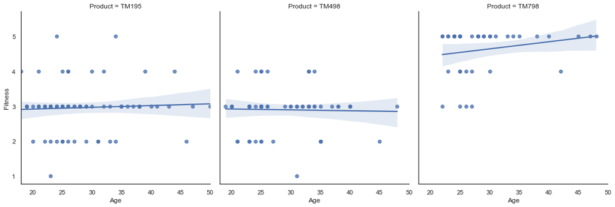

```python
sns.lmplot(x='Age', y='Fitness', col='Product', data=cardio_df);
```

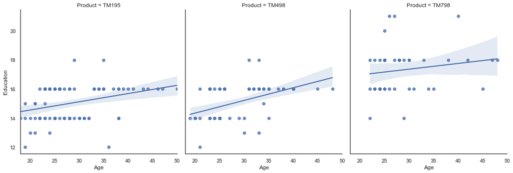

```python
sns.lmplot(x='Age', y='Education', col='Product', data=cardio_df);
```

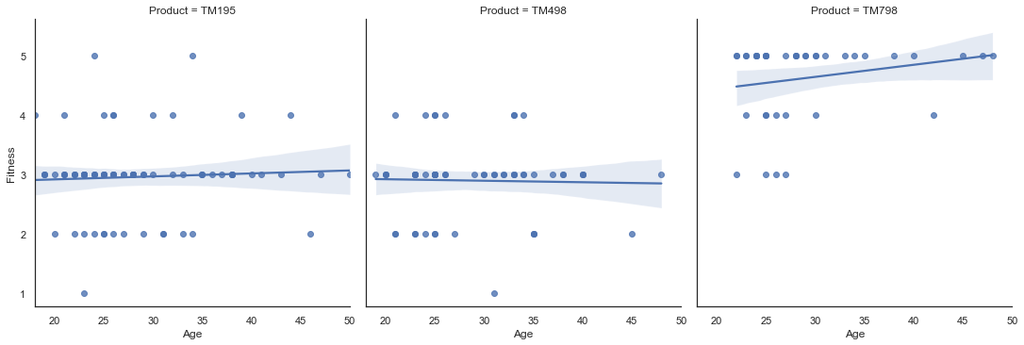

```python
sns.lmplot(x='Age', y='Fitness', col='Product', data=cardio_df);
```

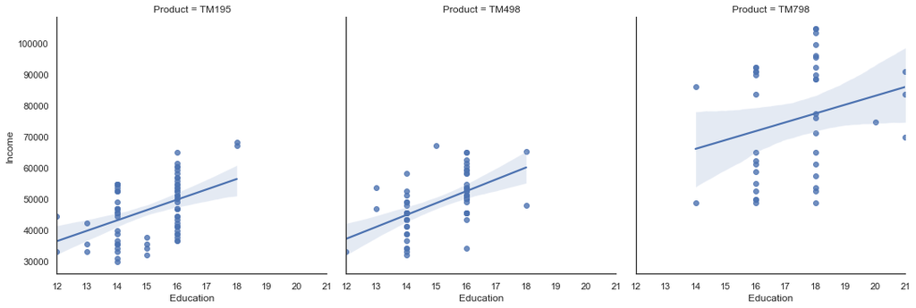

```python
sns.lmplot(x='Education', y='Income', col='Product', data=cardio_df);
```

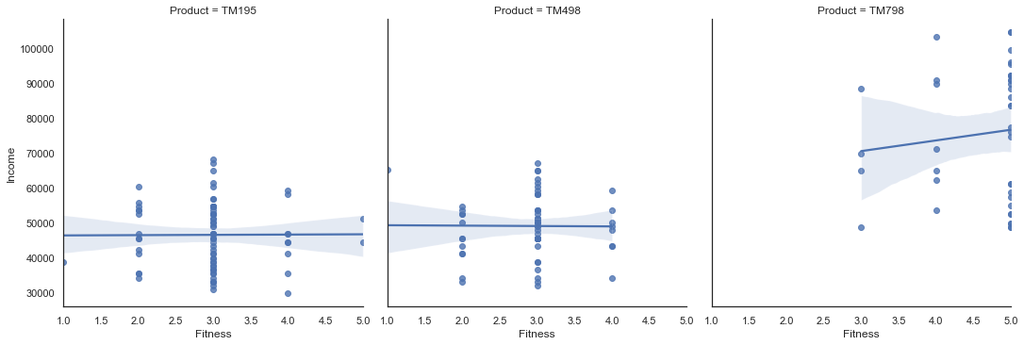

```python
sns.lmplot(x='Fitness', y='Income', col='Product', data=cardio_df);
```

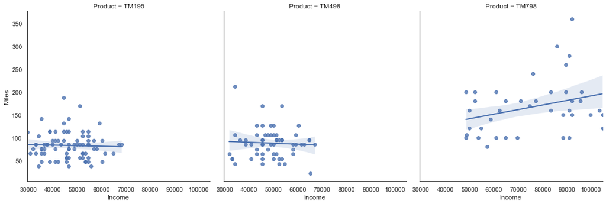

```python
sns.lmplot(x='Income', y='Miles', col='Product', data=cardio_df);
```

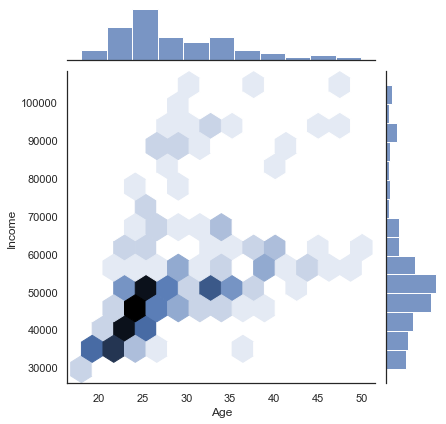

```python
sns.jointplot( x=cardio_df['Age'], y=cardio_df['Income'], kind='hex');
```

```python
correlation = cardio_df.corr()
```

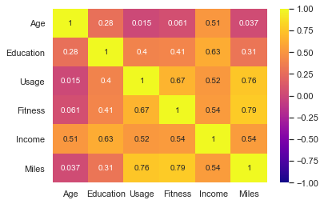

```python
sns.heatmap(correlation, annot=True, cmap='plasma', vmin=-1, vmax=1);
```

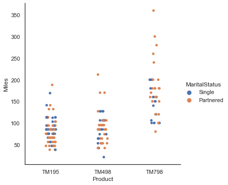

```python
sns.catplot(x="Product", y="Miles", hue="MaritalStatus", data=cardio_df);
```

**Observations:**

1. Doesn't appear that marriage is a mjor differentiator however, it does appear that partnered couple may create higher goals for themselves.